# Project: Investigate a Dataset - Database TMDb movie data

- Introduction
- Data Wrangling
- Exploratory Data Analysis
- Conclusions

## Introduction

### Dataset Description

This project uses The Movie Database (TMDb) movie metadata from Kaggle. It covers several thousand films with plot summaries, full ordered cast and crew credits, budgets, revenues, popularity, votes, release dates, production companies, and more. After a DMCA takedown affected an older IMDb-based version, Kaggle replaced it with this TMDb dataset, which provides more up‑to‑date revenue figures and some JSON-formatted fields.

- Key notes:
  - Values are user-contributed, so inconsistencies may occur.
  - Some columns are JSON-formatted.
  - Zero values in budget/revenue may indicate missing data rather than true zeros.
  - What are the most popular genres by year?
  - How have movie budgets, revenues, and ratings changed over time?

For full background, transfer details, column changes, caveats, and loading tips, see: [TMDb movie metadata](https://www.kaggle.com/datasets/tmdb/tmdb-movie-metadata).

### Questions for Analysis

- Which genres are most popular from year to year?
- What kinds of properties are associated with movies that have high revenues?
- Which movies are most efficient (profit to budget ratio)?
- Is there necessarily a relationship between high movie cost and high ratings?

```python
import pandas as pd
import numpy as np
import matplotlib.pyplot as plt
```

## Data Wrangling

### General Properties

```python
df = pd.read_csv('Database_TMDb_movie_data/tmdb-movies.csv')
```

```python
df.shape
```

```
(10866, 21)
```

```python
df.head()
```

|  | id | imdb_id | popularity | budget | revenue | original_title | cast | homepage | director | tagline | keywords | overview | runtime | genres | production_companies | release_date | vote_count | vote_average | release_year | budget_adj | revenue_adj |
| --- | --- | --- | --- | --- | --- | --- | --- | --- | --- | --- | --- | --- | --- | --- | --- | --- | --- | --- | --- | --- | --- |
| 0 | 135397 | tt0369610 | 32.985763 | 150000000 | 1513528810 | Jurassic World | Chris Pratt\|Bryce Dallas Howard\|Irrfan Khan\|Vi... | http://www.jurassicworld.com/ | Colin Trevorrow | The park is open. | monster\|dna\|tyrannosaurus rex\|velociraptor\|island | Twenty-two years after the events of Jurassic ... | 124 | Action\|Adventure\|Science Fiction\|Thriller | Universal Studios\|Amblin Entertainment\|Legenda... | 6/9/15 | 5562 | 6.5 | 2015 | 1.379999e+08 | 1.392446e+09 |
| 1 | 76341 | tt1392190 | 28.419936 | 150000000 | 378436354 | Mad Max: Fury Road | Tom Hardy\|Charlize Theron\|Hugh Keays-Byrne\|Nic... | http://www.madmaxmovie.com/ | George Miller | What a Lovely Day. | future\|chase\|post-apocalyptic\|dystopia\|australia | An apocalyptic story set in the furthest reach... | 120 | Action\|Adventure\|Science Fiction\|Thriller | Village Roadshow Pictures\|Kennedy Miller Produ... | 5/13/15 | 6185 | 7.1 | 2015 | 1.379999e+08 | 3.481613e+08 |
| 2 | 262500 | tt2908446 | 13.112507 | 110000000 | 295238201 | Insurgent | Shailene Woodley\|Theo James\|Kate Winslet\|Ansel... | http://www.thedivergentseries.movie/#insurgent | Robert Schwentke | One Choice Can Destroy You | based on novel\|revolution\|dystopia\|sequel\|dyst... | Beatrice Prior must confront her inner demons ... | 119 | Adventure\|Science Fiction\|Thriller | Summit Entertainment\|Mandeville Films\|Red Wago... | 3/18/15 | 2480 | 6.3 | 2015 | 1.012000e+08 | 2.716190e+08 |
| 3 | 140607 | tt2488496 | 11.173104 | 200000000 | 2068178225 | Star Wars: The Force Awakens | Harrison Ford\|Mark Hamill\|Carrie Fisher\|Adam D... | http://www.starwars.com/films/star-wars-episod... | J.J. Abrams | Every generation has a story. | android\|spaceship\|jedi\|space opera\|3d | Thirty years after defeating the Galactic Empi... | 136 | Action\|Adventure\|Science Fiction\|Fantasy | Lucasfilm\|Truenorth Productions\|Bad Robot | 12/15/15 | 5292 | 7.5 | 2015 | 1.839999e+08 | 1.902723e+09 |
| 4 | 168259 | tt2820852 | 9.335014 | 190000000 | 1506249360 | Furious 7 | Vin Diesel\|Paul Walker\|Jason Statham\|Michelle ... | http://www.furious7.com/ | James Wan | Vengeance Hits Home | car race\|speed\|revenge\|suspense\|car | Deckard Shaw seeks revenge against Dominic Tor... | 137 | Action\|Crime\|Thriller | Universal Pictures\|Original Film\|Media Rights ... | 4/1/15 | 2947 | 7.3 | 2015 | 1.747999e+08 | 1.385749e+09 |

```python
df.info()
```

```
<class 'pandas.core.frame.DataFrame'>
RangeIndex: 10866 entries, 0 to 10865
Data columns (total 21 columns):
 #   Column                Non-Null Count  Dtype
---  ------                --------------  -----
 0   id                    10866 non-null  int64
 1   imdb_id               10856 non-null  object
 2   popularity            10866 non-null  float64
 3   budget                10866 non-null  int64
 4   revenue               10866 non-null  int64
 5   original_title        10866 non-null  object
 6   cast                  10790 non-null  object
 7   homepage              2936 non-null   object
 8   director              10822 non-null  object
 9   tagline               8042 non-null   object
 10  keywords              9373 non-null   object
 11  overview              10862 non-null  object
 12  runtime               10866 non-null  int64
 13  genres                10843 non-null  object
 14  production_companies  9836 non-null   object
 15  release_date          10866 non-null  object
 16  vote_count            10866 non-null  int64
 17  vote_average          10866 non-null  float64
 18  release_year          10866 non-null  int64
 19  budget_adj            10866 non-null  float64
 20  revenue_adj           10866 non-null  float64
dtypes: float64(4), int64(6), object(11)
memory usage: 1.7+ MB
```

```python
# Calculate the number of duplicate values in each column.
# This shows how many values in each column are repeated.
df.shape[0] - df.nunique()
```

```
id                          1
imdb_id                    11
popularity                 52
budget                  10309
revenue                  6164
original_title            295
cast                      147
homepage                 7970
director                 5799
tagline                  2869
keywords                 2062
overview                   19
runtime                 10619
genres                   8827
production_companies     3421
release_date             4957
vote_count               9577
vote_average            10794
release_year            10810
budget_adj               8252
revenue_adj              6026
dtype: int64
```

```python
# This shows how many missing (null) values
# are in each column of the dataframe.
df.isnull().sum()
```

```
id                         0
imdb_id                   10
popularity                 0
budget                     0
revenue                    0
original_title             0
cast                      76
homepage                7930
director                  44
tagline                 2824
keywords                1493
overview                   4
runtime                    0
genres                    23
production_companies    1030
release_date               0
vote_count                 0
vote_average               0
release_year               0
budget_adj                 0
revenue_adj                0
dtype: int64
```

### Data Cleaning

```python
# Remove duplicate movies based on 'id'
df_cleaning = df.copy()
df_cleaning = df_cleaning.drop_duplicates(subset='id', keep='first')
df_cleaning.shape
```

```
(10865, 21)
```

##### Since our analysis will focus on the 'genres' column, we need to make sure there are no missing values in this column.

We'll drop any rows where 'genres' is null so our results are accurate.

```python
df_cleaning = df_cleaning.dropna(subset=['genres'])
df_cleaning.shape
```

```
(10842, 21)
```

##### In the next cell, we will keep only the adjusted budget and revenue columns.

##### These columns (ending with "_adj") show the budget and revenue in 2010 dollars, which accounts for inflation.

##### We will drop the original 'budget' and 'revenue' columns and rename the adjusted columns for easier analysis.

```python
df_cleaning = (
    df_cleaning
    .drop(columns=['budget','revenue'])
    .rename(columns={'budget_adj':'budget','revenue_adj':'revenue'})
    )
```

#### Data Formatting

In the next two cells, we will clean up the data in some columns. We will split the text in the 'cast', 'keywords', 'production_companies', and 'genres' columns into lists. This will make it easier to analyze and work with these categories later. After that, we will look at the first few rows of the cleaned data to make sure the changes worked.

```python
categories_col = ['cast','keywords','production_companies', 'genres']
for category in categories_col:
    df_cleaning[category] = df_cleaning[category].str.split('|')
```

```python
df_cleaning.head()
```

|  | id | imdb_id | popularity | original_title | cast | homepage | director | tagline | keywords | overview | runtime | genres | production_companies | release_date | vote_count | vote_average | release_year | budget | revenue |
| --- | --- | --- | --- | --- | --- | --- | --- | --- | --- | --- | --- | --- | --- | --- | --- | --- | --- | --- | --- |
| 0 | 135397 | tt0369610 | 32.985763 | Jurassic World | [Chris Pratt, Bryce Dallas Howard, Irrfan Khan... | http://www.jurassicworld.com/ | Colin Trevorrow | The park is open. | [monster, dna, tyrannosaurus rex, velociraptor... | Twenty-two years after the events of Jurassic ... | 124 | [Action, Adventure, Science Fiction, Thriller] | [Universal Studios, Amblin Entertainment, Lege... | 6/9/15 | 5562 | 6.5 | 2015 | 1.379999e+08 | 1.392446e+09 |
| 1 | 76341 | tt1392190 | 28.419936 | Mad Max: Fury Road | [Tom Hardy, Charlize Theron, Hugh Keays-Byrne,... | http://www.madmaxmovie.com/ | George Miller | What a Lovely Day. | [future, chase, post-apocalyptic, dystopia, au... | An apocalyptic story set in the furthest reach... | 120 | [Action, Adventure, Science Fiction, Thriller] | [Village Roadshow Pictures, Kennedy Miller Pro... | 5/13/15 | 6185 | 7.1 | 2015 | 1.379999e+08 | 3.481613e+08 |
| 2 | 262500 | tt2908446 | 13.112507 | Insurgent | [Shailene Woodley, Theo James, Kate Winslet, A... | http://www.thedivergentseries.movie/#insurgent | Robert Schwentke | One Choice Can Destroy You | [based on novel, revolution, dystopia, sequel,... | Beatrice Prior must confront her inner demons ... | 119 | [Adventure, Science Fiction, Thriller] | [Summit Entertainment, Mandeville Films, Red W... | 3/18/15 | 2480 | 6.3 | 2015 | 1.012000e+08 | 2.716190e+08 |
| 3 | 140607 | tt2488496 | 11.173104 | Star Wars: The Force Awakens | [Harrison Ford, Mark Hamill, Carrie Fisher, Ad... | http://www.starwars.com/films/star-wars-episod... | J.J. Abrams | Every generation has a story. | [android, spaceship, jedi, space opera, 3d] | Thirty years after defeating the Galactic Empi... | 136 | [Action, Adventure, Science Fiction, Fantasy] | [Lucasfilm, Truenorth Productions, Bad Robot] | 12/15/15 | 5292 | 7.5 | 2015 | 1.839999e+08 | 1.902723e+09 |
| 4 | 168259 | tt2820852 | 9.335014 | Furious 7 | [Vin Diesel, Paul Walker, Jason Statham, Miche... | http://www.furious7.com/ | James Wan | Vengeance Hits Home | [car race, speed, revenge, suspense, car] | Deckard Shaw seeks revenge against Dominic Tor... | 137 | [Action, Crime, Thriller] | [Universal Pictures, Original Film, Media Righ... | 4/1/15 | 2947 | 7.3 | 2015 | 1.747999e+08 | 1.385749e+09 |

#### Date Formatting

- In the next cells, we will convert the 'release_date' column from string format (MM/DD/YY) to datetime format.
- We'll split the dataset into two parts: movies released from 2000 onwards (df_20) and movies released before 2000 (df_19).
- For pre-2000 movies, we'll need to adjust the years since the two-digit year format can cause confusion (e.g., '99' could be interpreted as 2099 instead of 1999).
- This date conversion will allow us to perform time-based analysis and extract information like month, year, or day of week.

```python
# Convert year to integer and split data by century
df_cleaning['release_year'] = df_cleaning['release_year'].astype(int)

df_20 = df_cleaning.copy()  # For 2000+ movies
df_19 = df_cleaning.copy()  # For pre-2000 movies

df_20 = df_20[df_20['release_year'] >= 2000]
df_19 = df_19[df_19['release_year'] < 2000]
```

```python
df_20['release_date'] = (
    pd.to_datetime(df_20['release_date'],format='%m/%d/%y')
)
```

```python
df_20['release_date'].describe()
```

```
count                             7149
mean     2009-07-11 15:02:47.687788288
min                2000-01-01 00:00:00
25%                2006-04-05 00:00:00
50%                2010-01-14 00:00:00
75%                2013-05-13 00:00:00
max                2015-12-31 00:00:00
Name: release_date, dtype: object
```

```python
# Convert release dates to datetime format
df_19['release_date'] = pd.to_datetime(df_19['release_date'], format='%m/%d/%y')

# Fix the century issue for dates appearing after 2000 (these should be 19xx not 20xx)
mask = df_19['release_date'] > pd.to_datetime('2000-01-01')
df_19.loc[mask, 'release_date'] = df_19.loc[mask, 'release_date'] - pd.DateOffset(years=100)

# Show statistics about the release dates
df_19['release_date'].describe()
```

```
count                             3693
mean     1986-12-14 20:32:33.533712448
min                1960-01-01 00:00:00
25%                1980-09-19 00:00:00
50%                1989-05-24 00:00:00
75%                1995-07-18 00:00:00
max                1999-12-31 00:00:00
Name: release_date, dtype: object
```

```python
df_cleaned = pd.concat([df_19, df_20])
```

```python
df_cleaned = df_cleaned[(df_cleaned['revenue'] > 0) & (df_cleaned['budget'] > 0)]
df_cleaned.shape
```

```
(3854, 19)
```

```python
### Which genres are most popular from year to year?
```

## EDA

Let's analyze the most common genre by year. This will help us understand how movie genre preferences have changed over time. We'll first need to explode the genres list to work with individual genres, then use mode() to find the most common genre for each year.

```python
# Analysis of most popular genres by year
df_genres = df_cleaned.copy()
df_genres = df_genres.explode('genres')

# Group by release_year and find the most common genre for each year
genre_by_year = df_genres.groupby('release_year')['genres'].agg(lambda x: x.mode()[0])
genre_by_year = pd.DataFrame(genre_by_year)
display(genre_by_year)
```

| release_year | genres |
| --- | --- |
| 1960 | Drama |
| 1961 | Drama |
| 1962 | Drama |
| 1963 | Drama |
| 1964 | Drama |
| 1965 | Drama |
| 1966 | Action |
| 1967 | Drama |
| 1968 | Drama |
| 1969 | Adventure |
| 1970 | Drama |
| 1971 | Thriller |
| 1972 | Action |
| 1973 | Drama |
| 1974 | Drama |
| 1975 | Drama |
| 1976 | Drama |
| 1977 | Drama |
| 1978 | Drama |
| 1979 | Drama |
| 1980 | Drama |
| 1981 | Comedy |
| 1982 | Drama |
| 1983 | Thriller |
| 1984 | Action |
| 1985 | Comedy |
| 1986 | Drama |
| 1987 | Comedy |
| 1988 | Comedy |
| 1989 | Comedy |
| 1990 | Drama |
| 1991 | Comedy |
| 1992 | Drama |
| 1993 | Drama |
| 1994 | Comedy |
| 1995 | Drama |
| 1996 | Drama |
| 1997 | Thriller |
| 1998 | Drama |
| 1999 | Comedy |
| 2000 | Drama |
| 2001 | Comedy |
| 2002 | Drama |
| 2003 | Comedy |
| 2004 | Comedy |
| 2005 | Drama |
| 2006 | Drama |
| 2007 | Drama |
| 2008 | Drama |
| 2009 | Drama |
| 2010 | Drama |
| 2011 | Drama |
| 2012 | Drama |
| 2013 | Drama |
| 2014 | Drama |
| 2015 | Drama |

### What are the most popular genres by year?

This chart shows how different movie genres have become more or less popular over time. We can see which types of movies audiences preferred in different decades and how movie trends have changed from the 1960s to 2015.

```
Genre Statistics by Year:
              total_movies most_popular_genre  unique_genres
release_year
1960                    14              Drama              9
1961                    24              Drama             13
1962                    16              Drama              8
1963                    19              Drama             10
1964                    22              Drama             12
1965                    15              Drama             10
1966                    12             Action              9
1967                    39              Drama             13
1968                    27              Drama             14
1969                    10          Adventure              7
```

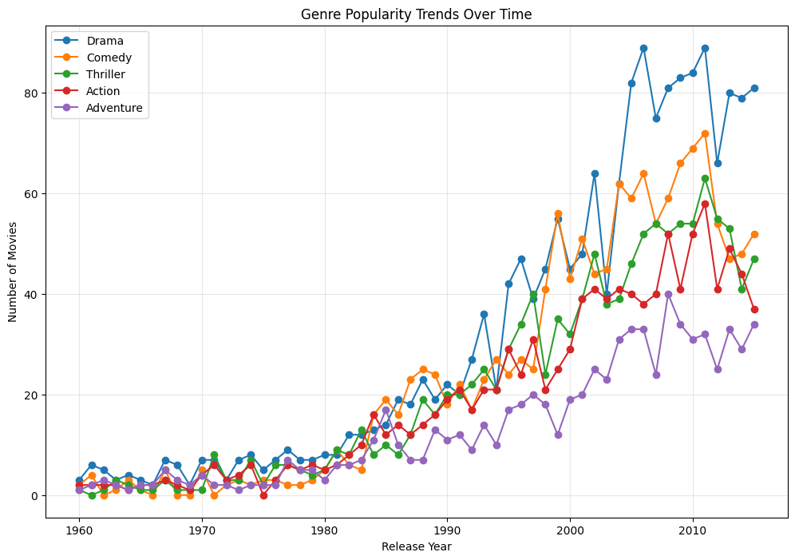

```python
# Analysis of most popular genres by year
# Statistics: Create a comprehensive statistical summary of the most popular genres by year
genre_stats = df_genres.groupby('release_year')['genres'].agg(['count', lambda x: x.mode()[0], 'nunique'])
genre_stats.columns = ['total_movies', 'most_popular_genre', 'unique_genres']
print("Genre Statistics by Year:")
print(genre_stats.head(10))

# Create a visualization showing genre popularity trends
plt.figure(figsize=(12, 8))
genre_counts = df_genres.groupby(['release_year', 'genres']).size().unstack(fill_value=0)
top_genres = genre_counts.sum().nlargest(5).index
for genre in top_genres:
    plt.plot(genre_counts.index, genre_counts[genre], label=genre, marker='o')

plt.title('Genre Popularity Trends Over Time')
plt.xlabel('Release Year')
plt.ylabel('Number of Movies')
plt.legend()
plt.grid(True, alpha=0.3)
plt.show()
```

### How have movie budgets, revenues, and ratings changed over time?

This section examines trends in key movie metrics from 1960 to 2015. We'll look at:

- Average movie budgets over the years
- Average revenues and how they've grown
- How audience ratings (vote averages) have changed

These trends help us understand how the movie industry has evolved and whether bigger budgets lead to higher revenues or better audience ratings.

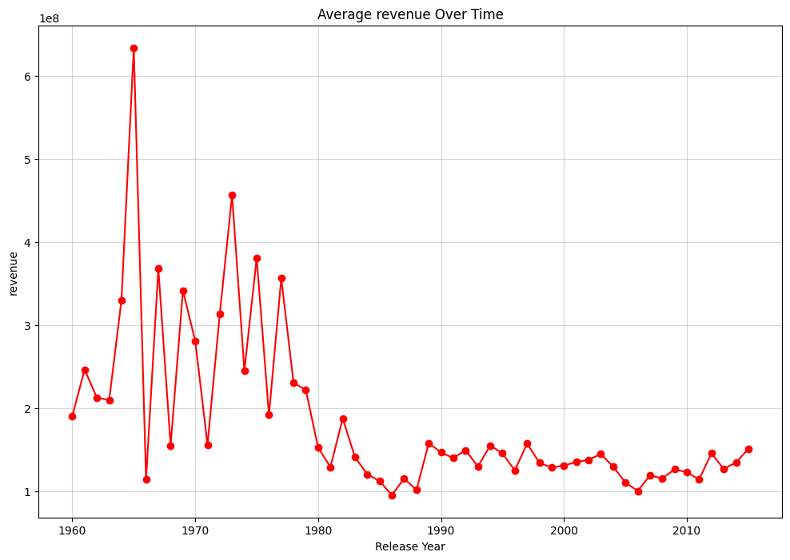

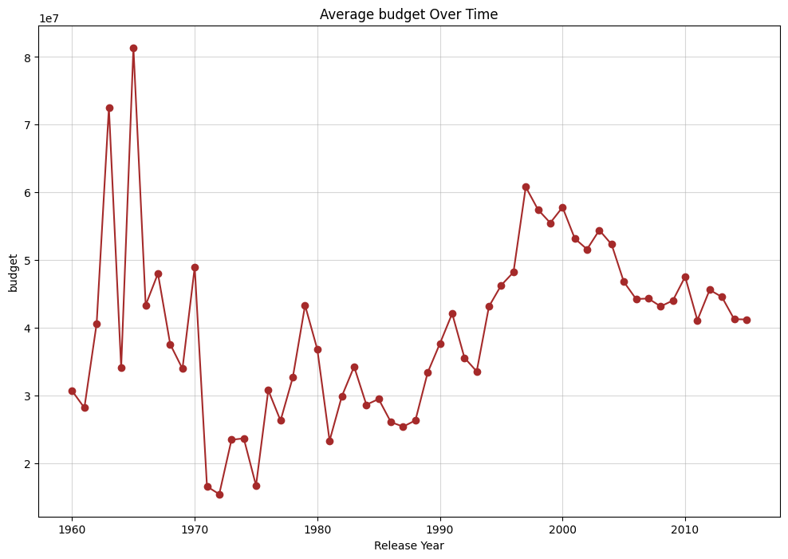

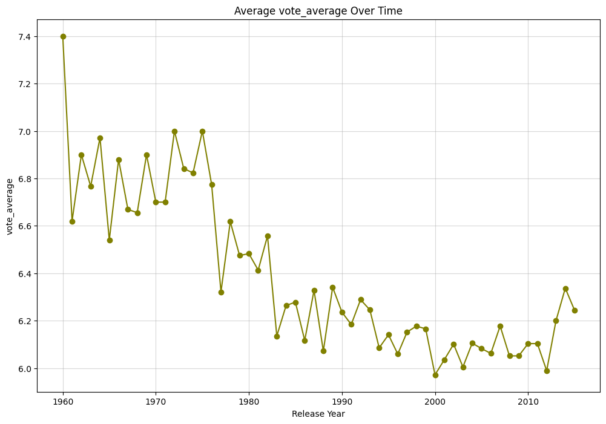

```python
# Calculate statistics by year
def create_line_plot(df,col):

    plt.figure(figsize=(12, 8))

    import random
    color = random.choice(['blue', 'red', 'green', 'orange', 'purple', 'brown', 'pink', 'gray', 'olive', 'cyan'])
    plt.plot(df.index, df[col], marker='o', color=color)

    plt.title(f'Average {col} Over Time')
    plt.xlabel('Release Year')
    plt.ylabel(col)
    plt.grid(True, alpha=0.5)
    plt.show();


statistics = df_cleaned.copy()
statistics = statistics.groupby('release_year').agg({
    'revenue':'mean',
    'budget':'mean',
    'vote_average':'mean',

})

for col in statistics.columns:
    create_line_plot(statistics,col)
```

### What kinds of properties are associated with movies that have high revenues?

In this section, we'll analyze what factors correlate with high-revenue movies. We'll identify movies in the top 10% by revenue and examine correlations between revenue and other numerical variables like budget, popularity, and vote metrics. This will help us understand what characteristics are common among financially successful films.

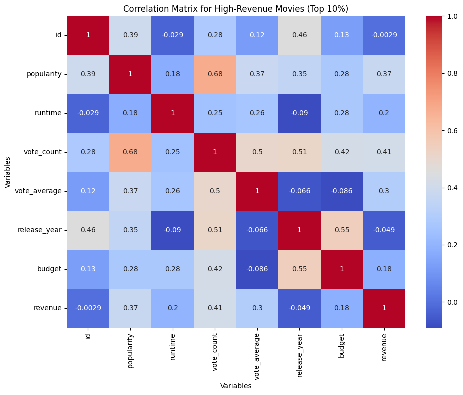

```python
# Analyzing high-revenue movies (top 10%)
df_most_revenue = df_cleaned[df_cleaned['revenue'] >= df_cleaned['revenue'].quantile(0.9)]

# Get numerical columns for correlation analysis
numurca_col = []
for col in df_most_revenue.columns:
    if df_most_revenue[col].dtype == 'float64' or df_most_revenue[col].dtype == 'int64':
        numurca_col.append(col)

# Create correlation heatmap
plt.figure(figsize=(10, 8))
correlation_matrix = df_most_revenue[numurca_col].corr()
heatmap = sns.heatmap(correlation_matrix, annot=True, cmap='coolwarm')
plt.title('Correlation Matrix for High-Revenue Movies (Top 10%)')
plt.xlabel('Variables')
plt.ylabel('Variables')
plt.tight_layout()
plt.show();
```

### Which movies are most efficient (profit to budget ratio)?

This analysis identifies films that generated the highest return on investment by calculating the ratio of revenue to budget, showing which movies were most financially efficient.

```python
df_most_efficient = df_cleaned.copy()
df_most_efficient['profit_ratio'] = round(df_most_efficient['revenue'] / df_most_efficient['budget'], 2)
df_most_efficient = df_most_efficient[['original_title','profit_ratio']].sort_values(by='profit_ratio', ascending=False).head(10)
print(df_most_efficient)
```

```
                original_title  profit_ratio
10495  The Karate Kid, Part II    1018619.28
6179            Into the Night      58771.93
3608        From Prada to Nada      26881.72
7447       Paranormal Activity      12890.39
2449   The Blair Witch Project       9920.00
3581   Love, Wedding, Marriage       1378.00
1354                Eraserhead        700.00
7277            Pink Flamingos        500.00
7178             Super Size Me        439.62
242                The Gallows        426.64
```

#### Which movies generated the highest absolute profit?

This analysis identifies the top 10 movies with the highest absolute profit (revenue minus budget), showing which films made the most money overall regardless of their budget size.

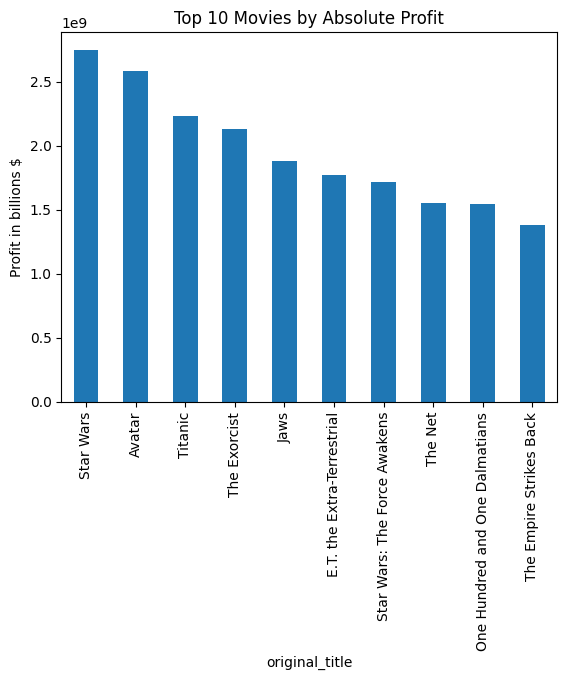

```python
df_most_profitable = df_cleaned.copy()
df_most_profitable['profit_ratio'] = df_most_profitable['revenue'] - df_most_profitable['budget']
df_most_profitable =(
    df_most_profitable[
        ['original_title','profit_ratio']
        ]
        .sort_values(by='profit_ratio', ascending=False)
        .head(10)
    )

(
    df_most_profitable
    .head(10)
    .plot(kind='bar', x='original_title', y='profit_ratio',
          title='Top 10 Movies by Absolute Profit',
          legend=False, ylabel='Profit in billions $')
);
```

[figure not shown]

```python
# Create a scatter plot to examine the relationship between movie budget and average vote rating

df_revenue_rating = df_cleaned.copy()
df_revenue_rating = df_revenue_rating[['revenue', 'vote_average']]

# Apply log transformation to budget to better visualize the relationship
df_revenue_rating['log_revenue'] = np.log10(df_revenue_rating['revenue'] + 1)  # Adding 1 to avoid log(0)

# Plot with clear labels and formatting
plt.figure(figsize=(10, 6))
df_revenue_rating.plot(
    kind='scatter',
    x='log_revenue',
    y='vote_average',
    alpha=0.5,
    title='Relationship Between Movie Budget (log scale) and Average Rating',
    figsize=(10, 6)
)
plt.xlabel('Revenue (log10 scale)')
plt.ylabel('Average Rating')
plt.grid(True, alpha=0.3)
```

## Conclusions

### Summary of Results

Based on the analysis of TMDb data (10,866 movies across multiple decades) and after cleaning and preparation steps, we answered key exploratory questions about genre popularity over time, characteristics of highest-grossing films, return-on-investment efficiency, absolute profits, and possible relationships between revenue/cost and ratings.

### Limitations

- **Data Quality and Completeness**: Multiple columns contain missing values. We removed rows with missing values in critical columns like genres, which may introduce sample bias.
- **Inflation and Currencies**: We used inflation-adjusted values, but these may not always reflect actual purchasing power differences across decades.
- **Genre Classification**: A film belonging to multiple genres complicates analysis. Choosing the "most common" for each year simplifies the reality of genre mixing.
- **Value Filtering**: Analysis was limited to films with positive revenues and budgets, which may exclude important cases and affect distributions.
- **Absence of Statistical Tests**: No statistical significance tests were performed; therefore, results are descriptive and correlational without inferring causality.

### Proposed Future Work

- Conduct statistical tests and multivariate regression models to test the strength of correlations.
- Isolate the effect of budget from popularity and vote count to understand the relative contributions of each factor.
- Integrate external data (marketing spending, release season, distribution and platforms, public opinion indicators) to expand context.
- Conduct longitudinal studies to track performance of genres or series over time instead of cross-sectional snapshots.
- Address outliers and rescale (such as winsorization) to improve metric stability.